# The Safety Dilemma Put to the Test

Isabelle Keßels, Paul Hasselkuß, Daian Bica

## Background

We want to investigate the following three claims (due to Kelp and Pritchard):

```
(K2E) FAKE BARNS will be evaluated <3, whereas DEMON will be evaluated >3.
(P1E) SHEEP, FAKE BARNS and DEMON will be evaluated <3 (contra K2).
(P3E) The difference in the type of luck in play will correspond to a difference in the type’s evaluation: modal luck (ML) > environmental luck (EL) > intervening luck (IL).
```

## Load and prepare data

This chunk reads in the raw (already pivoted, tidied, in long format) CSV data and recodes a few columns for readability and correct ordering.

```r
data <-
  read.csv2("./data.csv") %>%
  mutate(
    gender = fct_relevel(gender, "female", "male", "other"),
    theme = fct_relevel(theme, "various", "clock", "water"),
    luck = fct_recode(
      luck,
      "Intervening Luck (IL)" = "intervening",
      "Environmental Luck (EL)" = "environmental",
      "Modal Luck (ML)" = "modal"
    ),
    luck = fct_relevel(
      luck,
      "Intervening Luck (IL)",
      "Environmental Luck (EL)",
      "Modal Luck (ML)"
    ),
    vignette = recode(vignette, "demon clock" = "demon"),
    vignette = toupper(vignette),
    vignette = fct_reorder(
      vignette,
      as.numeric(luck) + 0.01 * as.numeric(theme) #order by luck, then by topic
    ),
    score = score - 1,
  ) %>%
  arrange(prolific_id, luck)

data
```

| luck | theme | vignette | score | first | gender | age | phil_class | order | consent | prolific_id | start | end | duration | int_name |
| --- | --- | --- | --- | --- | --- | --- | --- | --- | --- | --- | --- | --- | --- | --- |
| Intervening Luck (IL) | water | OFFICE WATER | 0 | FALSE | female | 38 | 0 | VAR_E\|CLOCK_I\|VAR_M\|CLOCK_M\|WATER_M\|WATER_I\|VAR_I\|WATER_E\|CLOCK_E | 1 | 5599dbe6fdf99b4a3c5bc628 | 2023-06-30T10:27:07Z | 2023-06-30T10:34:21Z | 433 | WATER_I |
| Intervening Luck (IL) | clock | STOPPED CLOCK | 6 | FALSE | female | 38 | 0 | VAR_E\|CLOCK_I\|VAR_M\|CLOCK_M\|WATER_M\|WATER_I\|VAR_I\|WATER_E\|CLOCK_E | 1 | 5599dbe6fdf99b4a3c5bc628 | 2023-06-30T10:27:07Z | 2023-06-30T10:34:21Z | 433 | CLOCK_I |
| Intervening Luck (IL) | various | SHEEP | 0 | FALSE | female | 38 | 0 | VAR_E\|CLOCK_I\|VAR_M\|CLOCK_M\|WATER_M\|WATER_I\|VAR_I\|WATER_E\|CLOCK_E | 1 | 5599dbe6fdf99b4a3c5bc628 | 2023-06-30T10:27:07Z | 2023-06-30T10:34:21Z | 433 | VAR_I |
| Environmental Luck (EL) | water | STATION WATER | 0 | FALSE | female | 38 | 0 | VAR_E\|CLOCK_I\|VAR_M\|CLOCK_M\|WATER_M\|WATER_I\|VAR_I\|WATER_E\|CLOCK_E | 1 | 5599dbe6fdf99b4a3c5bc628 | 2023-06-30T10:27:07Z | 2023-06-30T10:34:21Z | 433 | WATER_E |
| Environmental Luck (EL) | clock | CLOCK SHOP | 6 | FALSE | female | 38 | 0 | VAR_E\|CLOCK_I\|VAR_M\|CLOCK_M\|WATER_M\|WATER_I\|VAR_I\|WATER_E\|CLOCK_E | 1 | 5599dbe6fdf99b4a3c5bc628 | 2023-06-30T10:27:07Z | 2023-06-30T10:34:21Z | 433 | CLOCK_E |
| Environmental Luck (EL) | various | FAKE BARNS | 6 | TRUE | female | 38 | 0 | VAR_E\|CLOCK_I\|VAR_M\|CLOCK_M\|WATER_M\|WATER_I\|VAR_I\|WATER_E\|CLOCK_E | 1 | 5599dbe6fdf99b4a3c5bc628 | 2023-06-30T10:27:07Z | 2023-06-30T10:34:21Z | 433 | VAR_E |
| Modal Luck (ML) | water | WATER | 1 | FALSE | female | 38 | 0 | VAR_E\|CLOCK_I\|VAR_M\|CLOCK_M\|WATER_M\|WATER_I\|VAR_I\|WATER_E\|CLOCK_E | 1 | 5599dbe6fdf99b4a3c5bc628 | 2023-06-30T10:27:07Z | 2023-06-30T10:34:21Z | 433 | WATER_M |
| Modal Luck (ML) | clock | DEMON | 6 | FALSE | female | 38 | 0 | VAR_E\|CLOCK_I\|VAR_M\|CLOCK_M\|WATER_M\|WATER_I\|VAR_I\|WATER_E\|CLOCK_E | 1 | 5599dbe6fdf99b4a3c5bc628 | 2023-06-30T10:27:07Z | 2023-06-30T10:34:21Z | 433 | CLOCK_M |
| Modal Luck (ML) | various | VIDEO CALL | 6 | FALSE | female | 38 | 0 | VAR_E\|CLOCK_I\|VAR_M\|CLOCK_M\|WATER_M\|WATER_I\|VAR_I\|WATER_E\|CLOCK_E | 1 | 5599dbe6fdf99b4a3c5bc628 | 2023-06-30T10:27:07Z | 2023-06-30T10:34:21Z | 433 | VAR_M |
| Intervening Luck (IL) | water | OFFICE WATER | 2 | TRUE | female | 45 | 0 | WATER_I\|CLOCK_E\|CLOCK_M\|VAR_E\|CLOCK_I\|WATER_E\|VAR_M\|VAR_I\|WATER_M | 1 | 55a3e4e6fdf99b6e3e617d33 | 2023-06-30T10:28:06Z | 2023-06-30T10:34:05Z | 359 | WATER_I |

[output cut: 4670 more lines]

## Sample descriptives

Numbers of participants etc.

```r
participants <- data %>% distinct(prolific_id, age, gender, phil_class)

tibble(
  participants = n_distinct(data$prolific_id),
  ratings = nrow(data),
  vignettes = n_distinct(data$vignette)
)
```

| participants | ratings | vignettes |
| --- | --- | --- |
| 520 | 4680 | 9 |

```r
participants %>%
  summarise(
    mean_age = mean(age, na.rm = TRUE),
    sd_age = sd(age, na.rm = TRUE),
    min_age = min(age, na.rm = TRUE),
    max_age = max(age, na.rm = TRUE)
  )
```

| mean_age | sd_age | min_age | max_age |
| --- | --- | --- | --- |
| 39.95769 | 13.69859 | 18 | 77 |

```r
participants %>% count(gender) %>% mutate(prop = round(n / sum(n), 3))
```

| gender | n | prop |
| --- | --- | --- |
| female | 257 | 0.494 |
| male | 261 | 0.502 |
| other | 2 | 0.004 |

```r
participants %>% count(phil_class) %>% mutate(prop = round(n / sum(n), 3))
```

| phil_class | n | prop |
| --- | --- | --- |
| 0 | 457 | 0.879 |
| 1 | 63 | 0.121 |

## Distribution of scores per vignette

Distribution of scores for each vignette (3 x 3 grid: one panel per vignette, grouped by luck type as rows). The tests are reported in the table below.

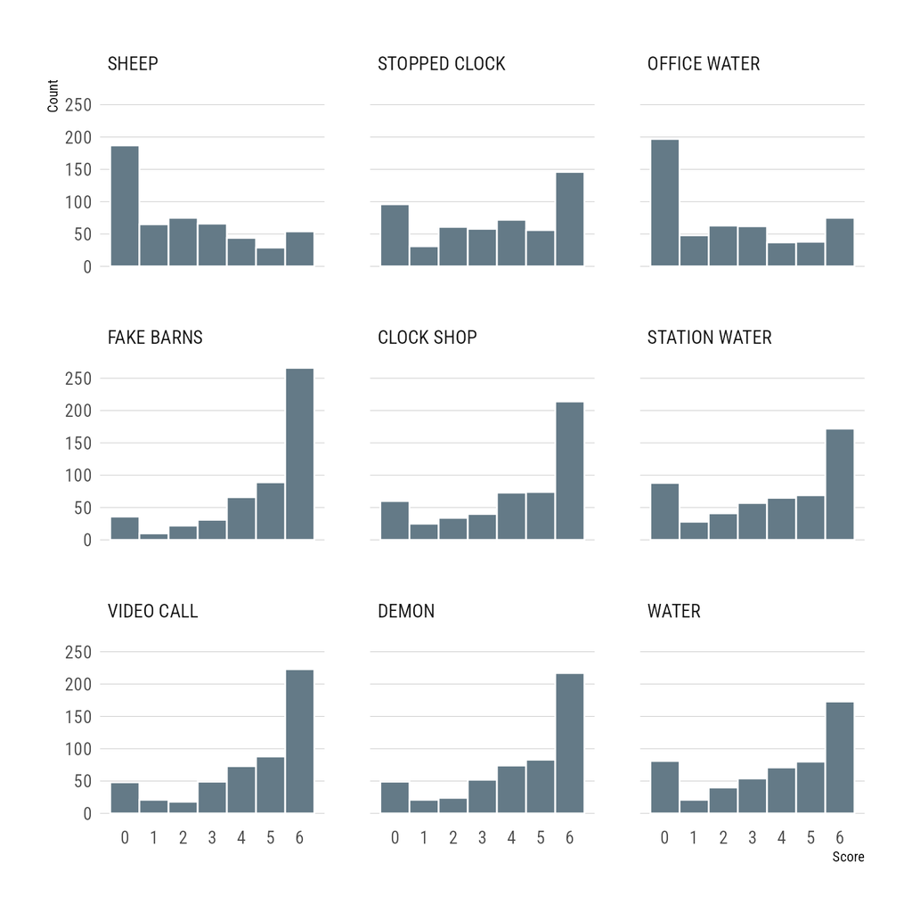

```r
ggplot(data, aes(x = score)) +
  geom_histogram(binwidth = 1, fill = "#647A87", color = "white") +
  facet_wrap(vars(vignette), ncol = 3) +
  scale_x_continuous(breaks = 0:6) +
  scale_y_continuous(breaks = seq(0, 250, 50), limits = c(0, 275)) +
  labs(x = "Score", y = "Count") +
  theme_ipsum_rc(grid = "Y", subtitle_size = 10)
```

## Tests against the scale midpoint (K2E, P1E)

For the three vignettes named in K2E and P1E, we test whether the mean score differs from the midpoint 3 (0-6 scale, i.e. after `score - 1`). Both one-sided alternatives are reported: “less” supports `< 3` (P1E; K2E for FAKE BARNS), “greater” supports `> 3` (K2E for DEMON). We report a one-sample t-test and, as a robustness check given the bounded, skewed scores, a Wilcoxon signed-rank test (test statistic V). Effect sizes are one-sample Cohen’s d = (M - 3) / SD with a 95% CI based on the noncentral t distribution. p-values are Holm-adjusted across the vignettes within each test and direction.

```r
midpoint <- 3

# 95% CI for the one-sample Cohen's d = (M - mu) / SD, via the noncentral t
# distribution: find the ncp values for which the observed t is the
# upper / lower alpha/2 quantile, then rescale by sqrt(n).
cohens_d_ci <- function(x, mu, level = 0.95) {
  n <- length(x)
  d <- (mean(x) - mu) / sd(x)
  t_obs <- d * sqrt(n)
  a <- (1 - level) / 2
  ncp_limit <- function(p) {
    uniroot(
      function(ncp) pt(t_obs, df = n - 1, ncp = ncp) - p,
      interval = c(t_obs - 5, t_obs + 5)
    )$root
  }
  c(low = ncp_limit(1 - a), high = ncp_limit(a)) / sqrt(n)
}

midpoint_tests <- data %>%
  group_by(vignette) %>%
  group_modify(function(.x, .key) {
    x <- .x$score
    t_two <- t.test(x, mu = midpoint)
    d_ci <- cohens_d_ci(x, midpoint)
    tibble(
      n = length(x),
      mean = mean(x),
      sd = sd(x),
      median = median(x),
      ci_low = t_two$conf.int[1],
      ci_high = t_two$conf.int[2],
      cohens_d = (mean(x) - midpoint) / sd(x),
      d_ci_low = d_ci[["low"]],
      d_ci_high = d_ci[["high"]],
      t = unname(t_two$statistic),
      df = unname(t_two$parameter),
      p_t_two = t_two$p.value,
      p_t_less = t.test(x, mu = midpoint, alternative = "less")$p.value,
      p_t_greater = t.test(x, mu = midpoint, alternative = "greater")$p.value,
      # V is the same for both alternatives (sum of ranks of positive differences)
      w_V = unname(wilcox.test(x, mu = midpoint, exact = FALSE)$statistic),
      p_w_less = wilcox.test(x, mu = midpoint, alternative = "less", exact = FALSE)$p.value,
      p_w_greater = wilcox.test(x, mu = midpoint, alternative = "greater", exact = FALSE)$p.value
    )
  }) %>%
  ungroup() %>%
  mutate(across(
    c(p_t_two, p_t_less, p_t_greater, p_w_less, p_w_greater),
    ~ p.adjust(.x, method = "holm"),
    .names = "{.col}_holm"
  ))

# w_V (Wilcoxon V) is left unrounded so it can be reported exactly
midpoint_tests %>%
  mutate(across(where(is.numeric) & !w_V, ~ signif(.x, 3)))
```

| vignette | n | mean | sd | median | ci_low | ci_high | cohens_d | d_ci_low | d_ci_high | t | df | p_t_two | p_t_less | p_t_greater | w_V | p_w_less | p_w_greater | p_t_two_holm | p_t_less_holm | p_t_greater_holm | p_w_less_holm | p_w_greater_holm |
| --- | --- | --- | --- | --- | --- | --- | --- | --- | --- | --- | --- | --- | --- | --- | --- | --- | --- | --- | --- | --- | --- | --- |
| SHEEP | 520 | 2.03 | 2.05 | 2 | 1.86 | 2.21 | -0.471 | -0.5620 | -0.380 | -10.70 | 519 | 1.91e-24 | 9.56e-25 | 1.00e+00 | 25504.5 | 6.07e-22 | 1.00e+00 | 9.56e-24 | 8.61e-24 | 1.00e+00 | 5.46e-21 | 1.00e+00 |
| STOPPED CLOCK | 520 | 3.41 | 2.23 | 4 | 3.21 | 3.60 | 0.182 | 0.0955 | 0.269 | 4.16 | 519 | 3.80e-05 | 1.00e+00 | 1.90e-05 | 64595.0 | 1.00e+00 | 3.76e-05 | 3.80e-05 | 1.00e+00 | 5.70e-05 | 1.00e+00 | 1.13e-04 |
| OFFICE WATER | 520 | 2.21 | 2.22 | 2 | 2.02 | 2.40 | -0.356 | -0.4450 | -0.268 | -8.13 | 519 | 3.26e-15 | 1.63e-15 | 1.00e+00 | 31509.0 | 1.05e-14 | 1.00e+00 | 9.79e-15 | 1.31e-14 | 1.00e+00 | 8.37e-14 | 1.00e+00 |
| FAKE BARNS | 520 | 4.72 | 1.79 | 6 | 4.56 | 4.87 | 0.956 | 0.8520 | 1.060 | 21.80 | 519 | 2.94e-75 | 1.00e+00 | 1.47e-75 | 105260.0 | 1.00e+00 | 4.84e-51 | 2.65e-74 | 1.00e+00 | 1.32e-74 | 1.00e+00 | 4.36e-50 |
| CLOCK SHOP | 520 | 4.15 | 2.10 | 5 | 3.97 | 4.33 | 0.550 | 0.4570 | 0.642 | 12.50 | 519 | 1.12e-31 | 1.00e+00 | 5.62e-32 | 89069.0 | 1.00e+00 | 1.74e-26 | 6.74e-31 | 1.00e+00 | 3.37e-31 | 1.00e+00 | 1.05e-25 |
| STATION WATER | 520 | 3.69 | 2.23 | 4 | 3.50 | 3.88 | 0.308 | 0.2200 | 0.396 | 7.03 | 519 | 6.49e-12 | 1.00e+00 | 3.24e-12 | 71534.5 | 1.00e+00 | 1.10e-10 | 1.30e-11 | 1.00e+00 | 1.30e-11 | 1.00e+00 | 4.39e-10 |
| VIDEO CALL | 520 | 4.37 | 1.96 | 5 | 4.20 | 4.54 | 0.702 | 0.6060 | 0.798 | 16.00 | 519 | 3.62e-47 | 1.00e+00 | 1.81e-47 | 91134.0 | 1.00e+00 | 2.20e-35 | 2.90e-46 | 1.00e+00 | 1.45e-46 | 1.00e+00 | 1.76e-34 |
| DEMON | 520 | 4.30 | 1.97 | 5 | 4.13 | 4.47 | 0.660 | 0.5650 | 0.755 | 15.10 | 519 | 9.10e-43 | 1.00e+00 | 4.55e-43 | 88958.0 | 1.00e+00 | 3.21e-33 | 6.37e-42 | 1.00e+00 | 3.19e-42 | 1.00e+00 | 2.25e-32 |
| WATER | 520 | 3.82 | 2.17 | 4 | 3.63 | 4.00 | 0.376 | 0.2870 | 0.465 | 8.57 | 519 | 1.18e-16 | 1.00e+00 | 5.88e-17 | 75669.5 | 1.00e+00 | 3.56e-14 | 4.70e-16 | 1.00e+00 | 2.94e-16 | 1.00e+00 | 1.78e-13 |

## Linear mixed model (P3E)

P3E predicts an ordering of the luck types: ML > EL > IL. We therefore test two planned, one-sided contrasts (EL > IL and ML > EL) rather than all pairwise differences. Scores are modelled with a linear mixed model accounting for non-independence due to repeated measurements within participants and within vignettes.

Note that luck varies between vignettes (three vignettes per luck type), so the effective number of units for the luck effect is small (about 6 df).

### Random-effects structure

Luck varies within participants, so the maximal model includes by-participant random slopes for luck. We fit it first and keep the simpler random-intercept model only if the maximal one is singular.

```r
types_lmm_max <- lmer(
  score ~ luck + (1 + luck | prolific_id) + (1 | vignette),
  data = data
)
```

```
## boundary (singular) fit: see help('isSingular')
```

```r
isSingular(types_lmm_max)
```

```
## [1] TRUE
```

The maximal model is singular, so we use random intercepts for participants and vignettes. The planned contrasts are compared across both models below.

```r
types_lmm <- lmer(
  score ~ luck + (1 | prolific_id) + (1 | vignette),
  data = data
)
summary(types_lmm)
```

```
## Linear mixed model fit by REML. t-tests use Satterthwaite's method [
## lmerModLmerTest]
## Formula: score ~ luck + (1 | prolific_id) + (1 | vignette)
##    Data: data
##
## REML criterion at convergence: 19201.9
##
## Scaled residuals:
##     Min      1Q  Median      3Q     Max
## -3.0524 -0.6057  0.1174  0.6553  3.2096
##
## Random effects:
##  Groups      Name        Variance Std.Dev.
##  prolific_id (Intercept) 1.434    1.1976
##  vignette    (Intercept) 0.299    0.5468
##  Residual                2.916    1.7076
## Number of obs: 4680, groups:  prolific_id, 520; vignette, 9
##
## Fixed effects:
##                             Estimate Std. Error     df t value Pr(>|t|)
## (Intercept)                   2.5494     0.3229 6.3303   7.894 0.000167 ***
## luckEnvironmental Luck (EL)   1.6359     0.4506 6.0000   3.630 0.010962 *
## luckModal Luck (ML)           1.6154     0.4506 6.0000   3.585 0.011577 *
## ---
## Signif. codes:  0 '***' 0.001 '**' 0.01 '*' 0.05 '.' 0.1 ' ' 1
##
## Correlation of Fixed Effects:
##             (Intr) lEL(EL
## lckEnvL(EL) -0.698
## lckMdlL(ML) -0.698  0.500
```

### Omnibus test

As context, we test whether the luck type matters at all with a Type III F test using Satterthwaite’s method. Unlike a likelihood-ratio test against a model without `luck`, its denominator df (about 6) reflect that luck varies between only nine vignettes, in line with the planned contrasts below.

```r
anova(types_lmm)
```

|  | Sum Sq | Mean Sq | NumDF | DenDF | F value | Pr(>F) |
| --- | --- | --- | --- | --- | --- | --- |
| luck | 50.60519 | 25.30259 | 2 | 5.999953 | 8.677215 | 0.01695713 |

### Planned contrasts for P3E

`emm_options()` first raises internal size limits in `lmerTest`/`pbkrtest` so that degrees-of-freedom calculations aren’t skipped due to the dataset size. `emmeans` would use Kenward-Roger df by default; we request Satterthwaite df so that one method is used (and named) throughout, matching the coefficient table.

The two one-sided contrasts (EL > IL, ML > EL) are Holm-adjusted. The same contrasts from the maximal (singular) model are shown for comparison.

```r
emm_options(lmerTest.limit = nrow(data), pbkrtest.limit = nrow(data))

p3_contrasts <- list("EL - IL" = c(-1, 1, 0), "ML - EL" = c(0, -1, 1))

types_emm <- emmeans(types_lmm, ~ luck, lmer.df = "satterthwaite")

# Marginal means per luck type with 95% CIs
types_emm
```

```
##  luck                    emmean    SE   df lower.CL upper.CL
##  Intervening Luck (IL)     2.55 0.323 6.33     1.77     3.33
##  Environmental Luck (EL)   4.19 0.323 6.33     3.40     4.97
##  Modal Luck (ML)           4.16 0.323 6.33     3.38     4.95
##
## Degrees-of-freedom method: satterthwaite
## Confidence level used: 0.95
```

```r
# One-sided tests (H1: difference > 0), Holm-adjusted
contrast(types_emm, p3_contrasts, side = ">", adjust = "holm")
```

```
##  contrast estimate    SE df t.ratio p.value
##  EL - IL    1.6359 0.451  6   3.630  0.0110
##  ML - EL   -0.0205 0.451  6  -0.046  0.5174
##
## Degrees-of-freedom method: satterthwaite
## P value adjustment: holm method for 2 tests
## P values are right-tailed
```

```r
# Two-sided 95% CIs of the same contrasts
confint(contrast(types_emm, p3_contrasts))
```

|  | contrast | estimate | SE | df | lower.CL | upper.CL |
| --- | --- | --- | --- | --- | --- | --- |
| 1 | EL - IL | 1.63589744 | 0.4506245 | 5.999953 | 0.533257 | 2.738538 |
| 2 | ML - EL | -0.02051282 | 0.4506245 | 5.999953 | -1.123153 | 1.082128 |

```r
# Comparison: maximal model with random slopes
contrast(
  emmeans(types_lmm_max, ~ luck, lmer.df = "satterthwaite"),
  p3_contrasts, side = ">", adjust = "holm"
)
```

```
##  contrast estimate    SE   df t.ratio p.value
##  EL - IL    1.6359 0.452 6.09   3.617  0.0109
##  ML - EL   -0.0205 0.451 6.00  -0.046  0.5174
##
## Degrees-of-freedom method: satterthwaite
## P value adjustment: holm method for 2 tests
## P values are right-tailed
```

### Standardised contrasts

To give the contrasts a scale-free effect size, we divide them by the total SD of a rating, i.e. the square root of the summed variance components (participants + vignettes + residual). The CIs are the two-sided 95% CIs of the contrasts divided by the same constant (the SD is treated as fixed).

```r
sigma_total <- sqrt(sum(as.data.frame(VarCorr(types_lmm))$vcov))
sigma_total
```

```
## [1] 2.156207
```

```r
confint(contrast(types_emm, p3_contrasts)) %>%
  as_tibble() %>%
  mutate(across(
    c(estimate, lower.CL, upper.CL),
    ~ .x / sigma_total,
    .names = "{.col}_std"
  )) %>%
  select(contrast, estimate, lower.CL, upper.CL, ends_with("_std"))
```

| contrast | estimate | lower.CL | upper.CL | estimate_std | lower.CL_std | upper.CL_std |
| --- | --- | --- | --- | --- | --- | --- |
| EL - IL | 1.63589744 | 0.533257 | 2.738538 | 0.758692250 | 0.2473125 | 1.2700720 |
| ML - EL | -0.02051282 | -1.123153 | 1.082128 | -0.009513382 | -0.5208931 | 0.5018663 |

## ML vs EL: what the data can and cannot rule out

A non-significant ML vs EL difference is not evidence that the two types are the same, and an equivalence margin as wide as 1 scale point would not help the argument: it would still be compatible with the ordering ML > EL predicted by P3E. We therefore do not run a TOST with a fixed margin. Instead we report the 95% CI of ML - EL, i.e. the range of differences the data are compatible with, and the smallest margin at which equivalence would have been established (the larger absolute bound of the 90% CI).

```r
ml_el <- contrast(types_emm, list("ML - EL" = c(0, -1, 1)))
confint(ml_el)
```

|  | contrast | estimate | SE | df | lower.CL | upper.CL |
| --- | --- | --- | --- | --- | --- | --- |
| 1 | ML - EL | -0.02051282 | 0.4506245 | 5.999953 | -1.123153 | 1.082128 |

```r
ci90 <- confint(ml_el, level = 0.90)
max(abs(ci90$lower.CL), abs(ci90$upper.CL))
```

```
## [1] 0.8961587
```

## Robustness checks

### Vignette-level means

Luck is confounded with vignette, so we show the vignette means that the luck effect is based on.

```r
data %>%
  group_by(luck, theme, vignette) %>%
  summarise(mean = mean(score), sd = sd(score), .groups = "drop")
```

| luck | theme | vignette | mean | sd |
| --- | --- | --- | --- | --- |
| Intervening Luck (IL) | various | SHEEP | 2.034615 | 2.049191 |
| Intervening Luck (IL) | clock | STOPPED CLOCK | 3.405769 | 2.226735 |
| Intervening Luck (IL) | water | OFFICE WATER | 2.207692 | 2.223352 |
| Environmental Luck (EL) | various | FAKE BARNS | 4.715385 | 1.794810 |
| Environmental Luck (EL) | clock | CLOCK SHOP | 4.151923 | 2.095503 |
| Environmental Luck (EL) | water | STATION WATER | 3.688462 | 2.232848 |
| Modal Luck (ML) | various | VIDEO CALL | 4.373077 | 1.955981 |
| Modal Luck (ML) | clock | DEMON | 4.303846 | 1.974789 |
| Modal Luck (ML) | water | WATER | 3.817308 | 2.174313 |

### Theme as a fixed effect

Theme is crossed with luck (each vignette is one luck x theme cell).

```r
types_lmm_theme <- lmer(
  score ~ luck + theme + (1 | prolific_id) + (1 | vignette),
  data = data
)
contrast(
  emmeans(types_lmm_theme, ~ luck, lmer.df = "satterthwaite"),
  p3_contrasts, side = ">", adjust = "holm"
)
```

```
##  contrast estimate    SE df t.ratio p.value
##  EL - IL    1.6359 0.415  4   3.942  0.0169
##  ML - EL   -0.0205 0.415  4  -0.049  0.5185
##
## Results are averaged over the levels of: theme
## Degrees-of-freedom method: satterthwaite
## P value adjustment: holm method for 2 tests
## P values are right-tailed
```

### Ordinal mixed model

Scores are bounded and bimodal, so we check whether the ordering holds in a cumulative-link mixed model. The contrasts are on the latent scale and not comparable in size to the linear model. `clmm` warns about convergence for this model (max|grad| of about 2e-4 against a tolerance of 1e-6, iteration limit reached). We tried the available remedies without effect: `maxIter`, `maxLineIter` and `gradTol` in `clmm.control()` only govern the inner Newton loop, and the `ucminf` optimizer is not available for models with two random-effect terms. We therefore report this model as a sensitivity check and flag the warning. Moreover, `emmeans` uses asymptotic z tests for `clmm` models, which do not reflect that luck varies between only nine vignettes. We therefore use this model only to check the direction and relative size of the contrasts, not for inference.

```r
types_clmm <- ordinal::clmm(
  factor(score, ordered = TRUE) ~ luck + (1 | prolific_id) + (1 | vignette),
  data = data
)
```

```
## Warning: (-1) Model failed to converge with max|grad| = 0.000223147 (tol = 1e-06)
## In addition: iteration limit reached
```

```r
contrast(
  emmeans(types_clmm, ~ luck),
  p3_contrasts, side = ">", adjust = "holm"
)
```

```
##  contrast estimate    SE  df z.ratio p.value
##  EL - IL    1.7520 0.401 Inf   4.373 <0.0001
##  ML - EL   -0.0628 0.400 Inf  -0.157  0.5624
##
## Note: contrasts are still on the factor scale. Consider using
##       regrid() if you want contrasts of back-transformed estimates.
## P value adjustment: holm method for 2 tests
## P values are right-tailed
```